# Case study: unsupervised learning

2022-11-03

# Real example

Unsupervised techniques are often used in the analysis of genomic data. Here, we will analyze the `NCI60` data from the `ISLR2` package. These are cancer cell line microarray data, which consists of 6,830 gene expression measurements on 64 cancer cell lines.

```r
library(ISLR2)
nci_labs <- NCI60$labs
nci_data <- NCI60$data
```

The data are technically labeled with a cancer type, given in `nci_labs`. However, we will not use them in our clustering because we are performing unsupervised analysis!

In total, there are 14 true clusters or cancer types in the data:

```r
table(nci_labs)
```

```
## nci_labs
##      BREAST         CNS       COLON K562A-repro K562B-repro    LEUKEMIA
##           7           5           7           1           1           6
## MCF7A-repro MCF7D-repro    MELANOMA       NSCLC     OVARIAN    PROSTATE
##           1           1           8           9           6           2
##       RENAL     UNKNOWN
##           9           1
```

## K-means clustering

We will first perform $K$-means clustering. Begin by standardizing the variables to have mean zero and standard deviation of one using the `scale()` function. Then we will run $K$-means with $K=4$:

```r
std_data <- scale(nci_data)
set.seed(1)
km_out <- kmeans(std_data, 4, nstart = 20)
km_out$cluster
```

```
##  V1  V2  V3  V4  V5  V6  V7  V8  V9 V10 V11 V12 V13 V14 V15 V16 V17 V18 V19 V20
##   2   2   2   2   2   2   2   2   2   2   2   2   2   2   2   2   2   2   2   2
## V21 V22 V23 V24 V25 V26 V27 V28 V29 V30 V31 V32 V33 V34 V35 V36 V37 V38 V39 V40
##   2   2   2   4   4   2   4   2   4   2   2   4   4   3   3   3   3   3   3   3
## V41 V42 V43 V44 V45 V46 V47 V48 V49 V50 V51 V52 V53 V54 V55 V56 V57 V58 V59 V60
##   3   4   4   4   4   4   4   4   4   4   4   4   4   4   4   1   1   1   1   1
## V61 V62 V63 V64
##   1   1   1   1
```

Here, it seems like one cluster contains many more observations then there others.

We can examine if there are patterns by utilizing the true labels:

```r
table(cluster = km_out$cluster,  cancer = nci_labs)
```

```
##        cancer
## cluster BREAST CNS COLON K562A-repro K562B-repro LEUKEMIA MCF7A-repro
##       1      2   0     0           0           0        0           0
##       2      3   5     0           0           0        0           0
##       3      0   0     0           1           1        6           0
##       4      2   0     7           0           0        0           1
##        cancer
## cluster MCF7D-repro MELANOMA NSCLC OVARIAN PROSTATE RENAL UNKNOWN
##       1           0        7     0       0        0     0       0
##       2           0        1     4       3        1     9       1
##       3           0        0     0       0        0     0       0
##       4           1        0     5       3        1     0       0
```

What if we run the algorithm using the true number of clusters?

```r
set.seed(1)
km_out <- kmeans(std_data, 14, nstart = 20)
```

Ideally, we would want each type of cancer to land into a unique cluster. By creating a table of true labels and cluster assignments, this does not appear to be the case:

```r
table(cluster = km_out$cluster, cancer = nci_labs)
```

```
##        cancer
## cluster BREAST CNS COLON K562A-repro K562B-repro LEUKEMIA MCF7A-repro
##      1       0   0     0           1           1        1           0
##      2       0   0     6           0           0        0           0
##      3       1   1     0           0           0        0           0
##      4       0   0     0           0           0        0           0
##      5       0   3     0           0           0        0           0
##      6       0   0     1           0           0        0           0
##      7       0   0     0           0           0        2           0
##      8       0   0     0           0           0        0           0
##      9       2   0     0           0           0        0           1
##      10      0   0     0           0           0        0           0
##      11      2   0     0           0           0        0           0
##      12      2   1     0           0           0        0           0
##      13      0   0     0           0           0        0           0
```

[output cut: 17 more lines]

## Hierarchical clustering

We return to the `NCI60` data from the `ISLR2` package. These are cancer cell line microarray data, which consists of 6,830 gene expression measurements on 64 cancer cell lines. We first standardize the data. For the purposes of displaying the true cancer type, I will name the observations according to the cancer type:

```r
library(ISLR2)
nci_labs <- NCI60$labs
nci_data <- NCI60$data
std_data <- scale(nci_data)
rownames(std_data) <- nci_labs
```

Using complete linkage:

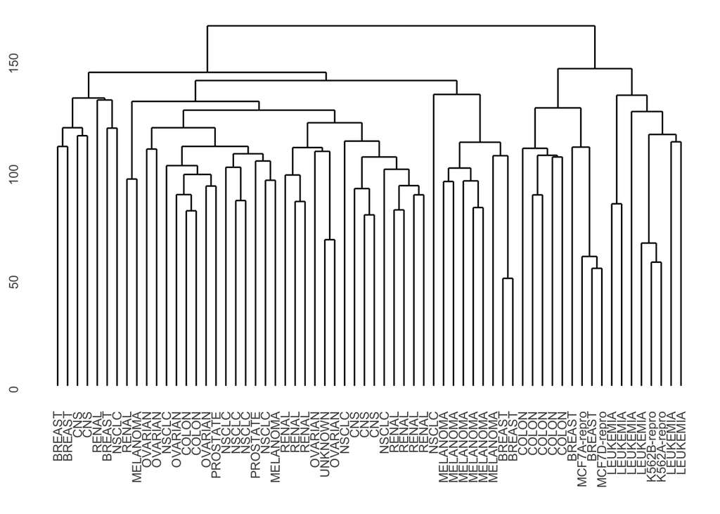

```r
data_dist <- dist(std_data)
hc_out <- hclust(data_dist, method = "complete")
ggdendrogram(hc_out)
```

Cutting the tree into 4 clusters and comparing to the truth:

```r
hc_clusters <- cutree(hc_out, 4)
table(hc_clusters, nci_labs)
```

```
##            nci_labs
## hc_clusters BREAST CNS COLON K562A-repro K562B-repro LEUKEMIA MCF7A-repro
##           1      2   3     2           0           0        0           0
##           2      3   2     0           0           0        0           0
##           3      0   0     0           1           1        6           0
##           4      2   0     5           0           0        0           1
##            nci_labs
## hc_clusters MCF7D-repro MELANOMA NSCLC OVARIAN PROSTATE RENAL UNKNOWN
##           1           0        8     8       6        2     8       1
##           2           0        0     1       0        0     1       0
##           3           0        0     0       0        0     0       0
##           4           1        0     0       0        0     0       0
```

We see that all of the Leukemia cancer cell lines fall into one cluster (cluster 3), whereas the breast cancer cell lines are spread out over three different clusters. If you recall, this same pattern was found when we used $K$-means with $K=4$ last week! However, these two methods will not agree perfectly.

The following code perform $K$-means clustering with $K=4$, then we compare the clusters to those of hierarchical clustering:

```r
set.seed(2)
km_out <- kmeans(std_data, 4, nstart = 20)
km_clusters <- km_out$cluster
table(km_clusters, hc_clusters)
```

```
##            hc_clusters
## km_clusters  1  2  3  4
##           1  0  0  8  0
##           2 11  0  0  9
##           3 20  7  0  0
##           4  9  0  0  0
```